# Bayesian modeling and prediction for movies

## Setup

### Load packages

```r
library(ggplot2)
library(dplyr)
library(statsr)
library(BAS)
library(descr)
library(moments)
```

### Load data

```r
load("movies.Rdata")
```

## Part 1: Data

This dataset is a sample of 651 films released between 1970 and 2014.

```r
count(movies)
```

```
## # A tibble: 1 x 1
##       n
##   <int>
## 1   651
```

```r
summary(movies$thtr_rel_year)
```

```
##    Min. 1st Qu.  Median    Mean 3rd Qu.    Max.
##    1970    1990    2000    1998    2007    2014
```

For all these movies several pieces of information have been collected regarding their year/month/day of released (in theatres and on DVD); the assessment they have received in two websites (Rotten Tomatoes and IMDb); so as many other features such as director, Oscar’s award, and the like. As for the information concerning the rating of the movies, it comes from two sources. Either it was willingly “watchers” of these movies who rated them based on their particular experience (this works for the audience scores/rating of Rotten Tomatoes and for the IMDb rating); or professional critics who rated them (see the variables critics_score, critics_rating). Because nothing makes imposible that the same persons may rate these movies in both websites, association between the two might be simply redundant or not interesting at all. However, we will assume that these websites adress different public and, therefore, the scores in one are not a simple repetition of the score in the other.

As for the **generabizability** of the result, given the size of the sample, hardly could we extrapolate results if we subdivided the sample by certain variable (for instance, genre). However, 651 random cases is enough to generalize when it comes to talk about the movies as a whole. Conversely, as the information is based on observational data, **no causalities** can be inferred from this dataset. Exclusively assocation between the variables is feasible based on this dataset.

## Part 2: Data manipulation

### *Feature Film*

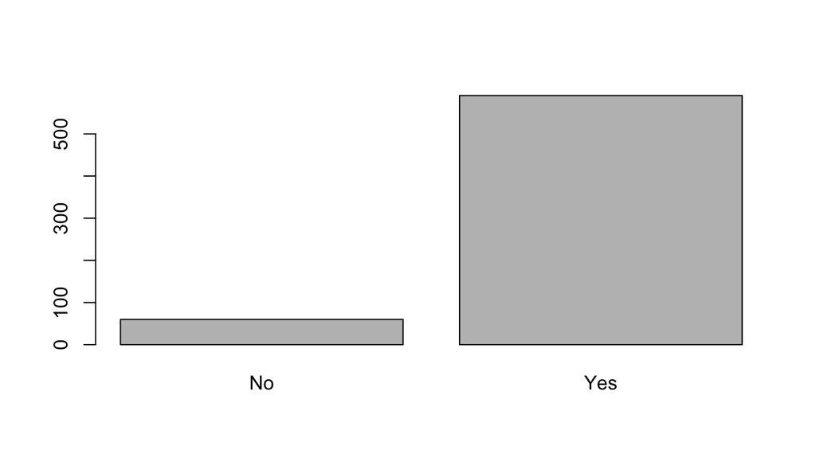

```
## movies$feature_film
##       Frequency Percent
## No           60   9.217
## Yes         591  90.783
## Total       651 100.000
```

```r
movies <- movies %>% mutate(feature_film = ifelse(title_type == "Feature Film", "Yes", "No"))
freq(movies$feature_film)
```

### *Drama*

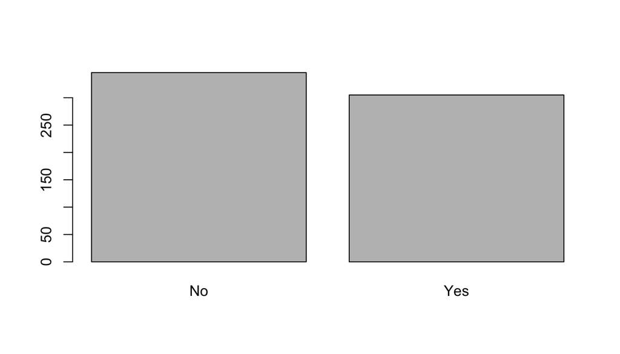

```
## movies$drama
##       Frequency Percent
## No          346   53.15
## Yes         305   46.85
## Total       651  100.00
```

```r
movies <- movies %>% mutate(drama = ifelse(genre == "Drama", "Yes", "No"))
freq(movies$drama)
```

### *Mpaa_rating_R*

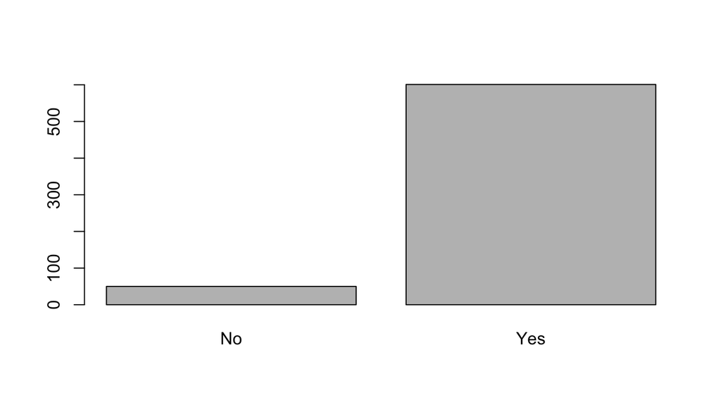

```
## movies$mpaa_rating_R
##       Frequency Percent
## No           50    7.68
## Yes         601   92.32
## Total       651  100.00
```

```r
movies <- movies %>% mutate(mpaa_rating_R = ifelse(mpaa_rating == "Unrated", "No", "Yes"))
freq(movies$mpaa_rating_R)
```

### *Oscar Season*

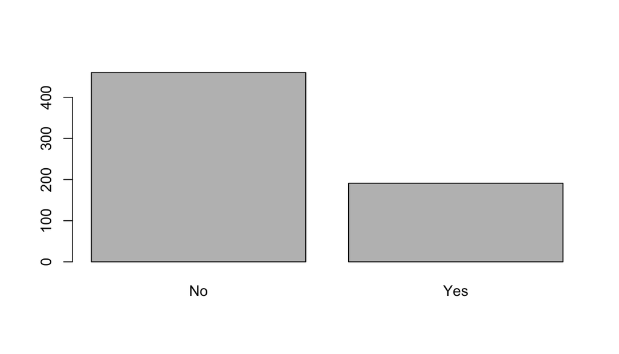

```
## movies$oscar_season
##       Frequency Percent
## No          460   70.66
## Yes         191   29.34
## Total       651  100.00
```

```r
movies <- movies %>% mutate(oscar_season = ifelse(thtr_rel_month >= 10, "Yes", "No"))
freq(movies$oscar_season)
```

### *Summer Season*

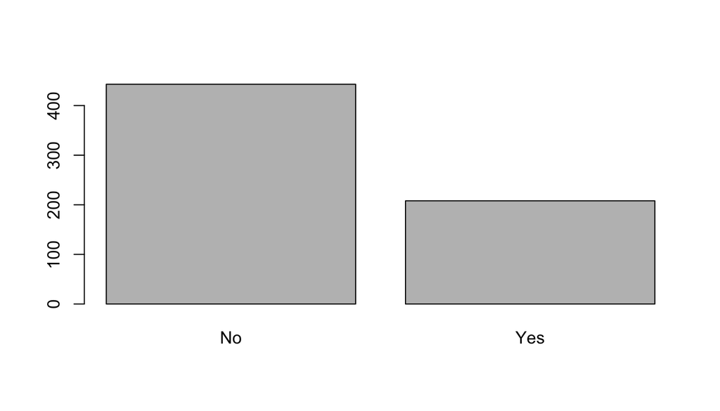

```
## movies$summer_season
##       Frequency Percent
## No          443   68.05
## Yes         208   31.95
## Total       651  100.00
```

```r
movies <- movies %>% mutate(summer_season = ifelse(
thtr_rel_month == 5, "Yes",
ifelse(thtr_rel_month == 6, "Yes",
ifelse(thtr_rel_month == 7, "Yes",
ifelse(thtr_rel_month == 8, "Yes", "No")))))
freq(movies$summer_season)
```

## Part 3: Exploratory data analysis

### *Audience score (univariate exploration)*

```r
summary_aud_score <- movies %>% summarise(mean_x = mean(audience_score), sd_x = sd(audience_score), median_x = median(audience_score), min_x = min(audience_score), max_x = max(audience_score), skew_x = skewness(audience_score))
round(summary_aud_score, 2)
```

```
## # A tibble: 1 x 6
##   mean_x  sd_x median_x min_x max_x skew_x
##    <dbl> <dbl>    <dbl> <dbl> <dbl>  <dbl>
## 1  62.36 20.22       65    11    97  -0.36
```

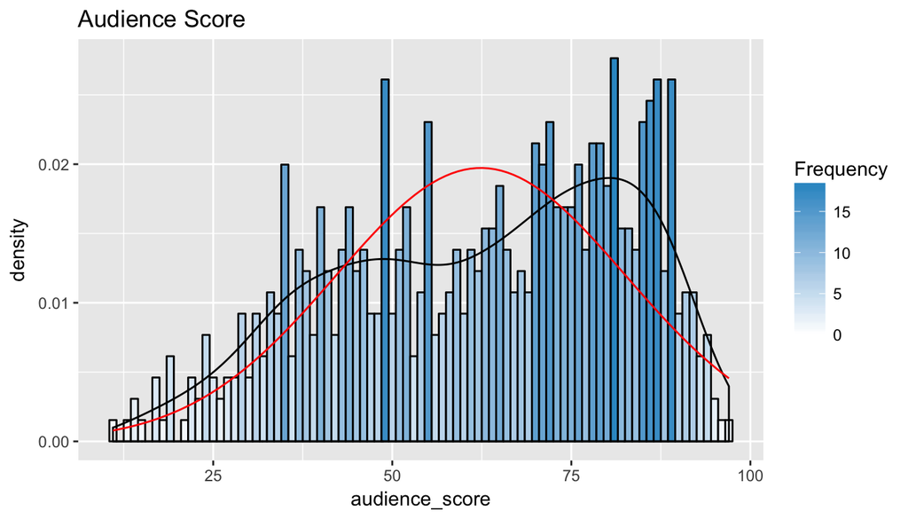

```r
ggplot(data = movies, aes(x = audience_score)) + geom_histogram(binwidth = 1, colour = "black", aes(y = ..density.., fill = ..count..)) + geom_density(alpha = .6) + scale_fill_gradient("Frequency", low= adjustcolor("#FFFFFF", alpha = .1), high= adjustcolor("#3399CC", alpha = .9)) + stat_function(fun = dnorm, colour = "red", args = list(mean = mean(movies$audience_score), sd = sd(movies$audience_score))) + ggtitle("Audience Score")
```

As we see above, audience score is a numeric variable. Its mean equals 62.36, however the values of the variable are highly spread; in addition, the distribution is left-skewed.

### *Audience Score by Feature Film*

```r
movies %>% group_by(feature_film) %>% summarise(count = n(), mean_x = mean(audience_score), sd_x = sd(audience_score), median_x = median(audience_score), min_x = min(audience_score), max_x = max(audience_score), skew_x = skewness(audience_score))
```

```
## # A tibble: 2 x 8
##   feature_film count   mean_x     sd_x median_x min_x max_x     skew_x
##          <chr> <int>    <dbl>    <dbl>    <dbl> <dbl> <dbl>      <dbl>
## 1           No    60 81.05000 13.57643     85.5    19    96 -3.0360355
## 2          Yes   591 60.46531 19.82402     62.0    11    97 -0.2598669
```

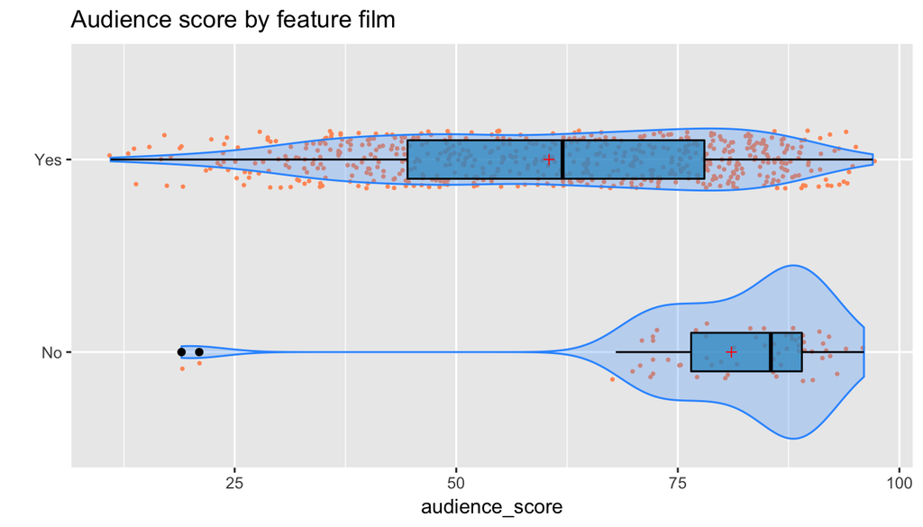

```r
ggplot(movies, aes(x = feature_film, y = audience_score)) + geom_jitter(colour = "#FF9966", size = .5, width = .15) + geom_violin(colour = "#3399FF", fill = adjustcolor("#3399FF", alpha = .25)) + geom_boxplot(width = .2, colour = "black", fill = adjustcolor("#3399CC", alpha = .75)) + ggtitle("Audience score by feature film") + coord_flip() + xlab("") + stat_summary(fun.y = mean, shape = 3, col = 'red', geom = 'point')
```

```r
regression1 <- lm(formula = audience_score ~ (feature_film - 1), data = movies)
summary(regression1)
```

```
##
## Call:
## lm(formula = audience_score ~ (feature_film - 1), data = movies)
##
## Residuals:
##     Min      1Q  Median      3Q     Max
## -62.050 -14.465   2.535  15.535  36.535
##
## Coefficients:
##                 Estimate Std. Error t value Pr(>|t|)
## feature_filmNo   81.0500     2.4967   32.46   <2e-16 ***
## feature_filmYes  60.4653     0.7955   76.01   <2e-16 ***
## ---
## Signif. codes:  0 '***' 0.001 '**' 0.01 '*' 0.05 '.' 0.1 ' ' 1
##
## Residual standard error: 19.34 on 649 degrees of freedom
## Multiple R-squared:  0.9132, Adjusted R-squared:  0.913
## F-statistic:  3415 on 2 and 649 DF,  p-value: < 2.2e-16
```

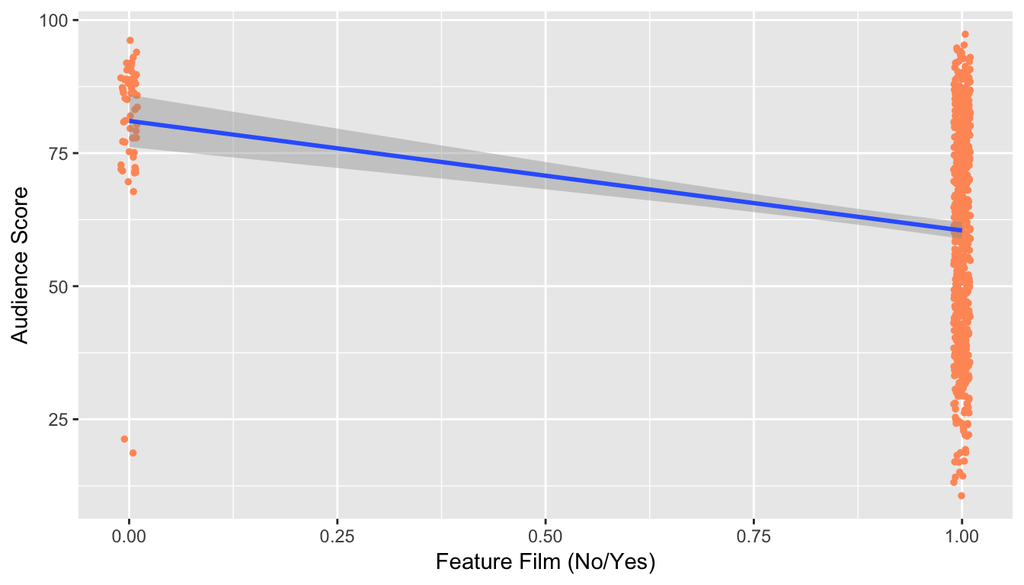

```r
ggplot(movies, aes(x = as.numeric(as.factor(feature_film)) - 1, y = audience_score)) + geom_jitter(colour = "#FF9966", size = 1, width = 0.01) + geom_smooth(method = "lm", se = TRUE) + xlab("Feature Film (No/Yes)") + ylab("Audience Score")
```

As we can see, between feature_film and audience_score there is a substantive negative association of more than 20 points of difference. The box-and-whiskers plot shows that setting aside a couple of non-feature films whose score is very low (less than 25), more than three-fourths of the distributions is above 75. Half of feature films, on the contrary, find themselves below an audience score of 62.

One potential problems here is the fact that the number of cases are very unevenly distributed between the two levels of feature_film. More than nine-tenths of the cases are feature films (591 out of 651). This might make the found association less reliable.

### *Audience Score by Drama*

```r
movies %>% group_by(drama) %>% summarise(count = n(), mean_x = mean(audience_score), sd_x = sd(audience_score), median_x = median(audience_score), min_x = min(audience_score), max_x = max(audience_score), skew_x = skewness(audience_score))
```

```
## # A tibble: 2 x 8
##   drama count   mean_x     sd_x median_x min_x max_x     skew_x
##   <chr> <int>    <dbl>    <dbl>    <dbl> <dbl> <dbl>      <dbl>
## 1    No   346 59.73121 21.27746       61    11    97 -0.1183854
## 2   Yes   305 65.34754 18.54184       70    13    95 -0.6576446
```

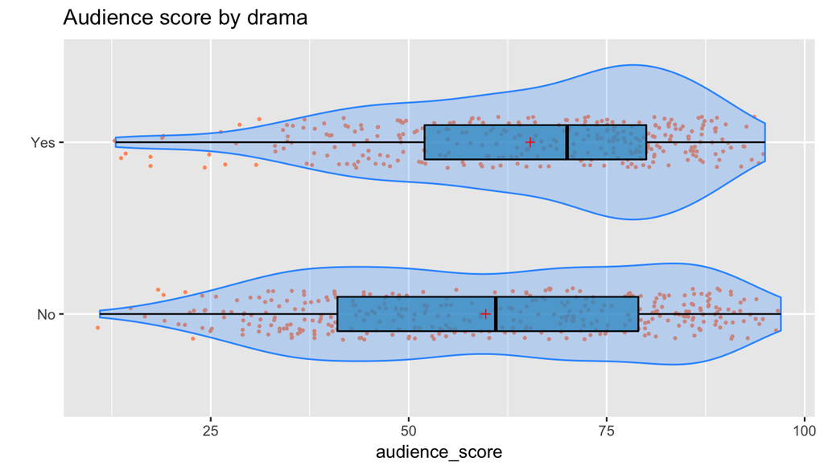

```r
ggplot(movies, aes(x = drama, y = audience_score)) + geom_jitter(colour = "#FF9966", size = .5, width = .15) + geom_violin(colour = "#3399FF", fill = adjustcolor("#3399FF", alpha = .25)) + geom_boxplot(width = .2, colour = "black", fill = adjustcolor("#3399CC", alpha = .75)) + ggtitle("Audience score by drama") + coord_flip() + xlab("") + stat_summary(fun.y = mean, shape = 3, col = 'red', geom = 'point')
```

```r
regression2 <- lm(formula = audience_score ~ (drama - 1), data = movies)
summary(regression2)
```

```
##
## Call:
## lm(formula = audience_score ~ (drama - 1), data = movies)
##
## Residuals:
##     Min      1Q  Median      3Q     Max
## -52.348 -16.348   3.269  15.961  37.269
##
## Coefficients:
##          Estimate Std. Error t value Pr(>|t|)
## dramaNo    59.731      1.077   55.44   <2e-16 ***
## dramaYes   65.348      1.148   56.94   <2e-16 ***
## ---
## Signif. codes:  0 '***' 0.001 '**' 0.01 '*' 0.05 '.' 0.1 ' ' 1
##
## Residual standard error: 20.04 on 649 degrees of freedom
## Multiple R-squared:  0.9068, Adjusted R-squared:  0.9065
## F-statistic:  3158 on 2 and 649 DF,  p-value: < 2.2e-16
```

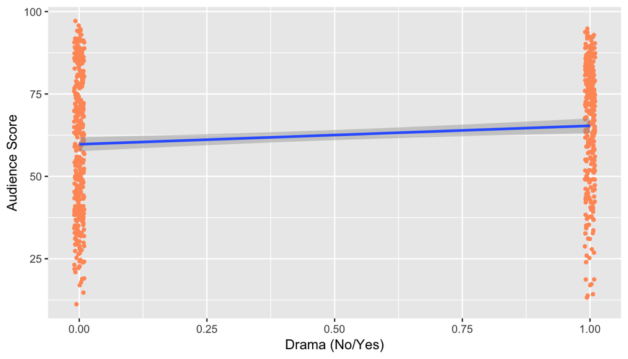

```r
ggplot(movies, aes(x = as.numeric(as.factor(drama)) - 1, y = audience_score)) + geom_jitter(colour = "#FF9966", size = 1, width = 0.01) + geom_smooth(method = "lm", se = TRUE) + xlab("Drama (No/Yes)") + ylab("Audience Score")
```

### *Audience Score by Mpaa Rating*

```r
movies %>% group_by(mpaa_rating_R) %>% summarise(count = n(), mean_x = mean(audience_score), sd_x = sd(audience_score), median_x = median(audience_score), min_x = min(audience_score), max_x = max(audience_score), skew_x = skewness(audience_score))
```

```
## # A tibble: 2 x 8
##   mpaa_rating_R count   mean_x     sd_x median_x min_x max_x     skew_x
##           <chr> <int>    <dbl>    <dbl>    <dbl> <dbl> <dbl>      <dbl>
## 1            No    50 78.48000 14.62349     81.5    19    96 -1.9914479
## 2           Yes   601 61.02163 20.05296     63.0    11    97 -0.2900906
```

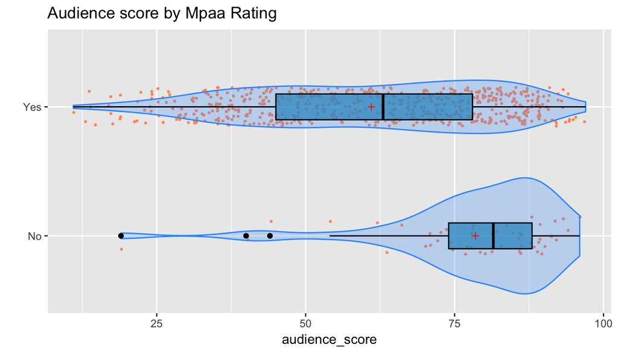

```r
ggplot(movies, aes(x = mpaa_rating_R, y = audience_score)) + geom_jitter(colour = "#FF9966", size = .5, width = .15) + geom_violin(colour = "#3399FF", fill = adjustcolor("#3399FF", alpha = .25)) + geom_boxplot(width = .2, colour = "black", fill = adjustcolor("#3399CC", alpha = .75)) + ggtitle("Audience score by Mpaa Rating") + coord_flip() + xlab("") + stat_summary(fun.y = mean, shape = 3, col = 'red', geom = 'point')
```

```r
regression3 <- lm(formula = audience_score ~ (mpaa_rating_R - 1), data = movies)
summary(regression3)
```

```
##
## Call:
## lm(formula = audience_score ~ (mpaa_rating_R - 1), data = movies)
##
## Residuals:
##     Min      1Q  Median      3Q     Max
## -59.480 -15.022   1.978  15.978  35.978
##
## Coefficients:
##                  Estimate Std. Error t value Pr(>|t|)
## mpaa_rating_RNo   78.4800     2.7853   28.18   <2e-16 ***
## mpaa_rating_RYes  61.0216     0.8034   75.95   <2e-16 ***
## ---
## Signif. codes:  0 '***' 0.001 '**' 0.01 '*' 0.05 '.' 0.1 ' ' 1
##
## Residual standard error: 19.7 on 649 degrees of freedom
## Multiple R-squared:   0.91,  Adjusted R-squared:  0.9097
## F-statistic:  3282 on 2 and 649 DF,  p-value: < 2.2e-16
```

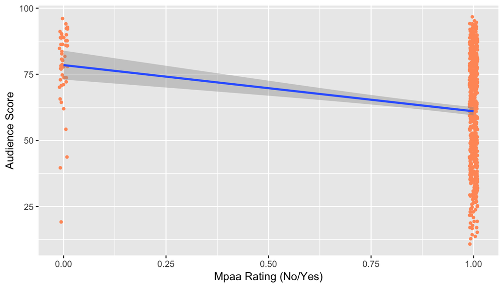

```r
ggplot(movies, aes(x = as.numeric(as.factor(mpaa_rating_R)) - 1, y = audience_score)) + geom_jitter(colour = "#FF9966", size = 1, width = 0.01) + geom_smooth(method = "lm", se = TRUE) + xlab("Mpaa Rating (No/Yes)") + ylab("Audience Score")
```

Between mpaa_rating_R and audience_score there is also a notable negative association of around 17.5 points. Thus, movie rated at mpaa is predicted to be scored much worse. However, as it happend with feature_film, the cases are very unevenly distributed between the two levels of the dichotomous variable.

### *Audience Score by Oscar Season*

```r
movies %>% group_by(oscar_season) %>% summarise(count = n(), mean_x = mean(audience_score), sd_x = sd(audience_score), median_x = median(audience_score), min_x = min(audience_score), max_x = max(audience_score), skew_x = skewness(audience_score))
```

```
## # A tibble: 2 x 8
##   oscar_season count   mean_x     sd_x median_x min_x max_x     skew_x
##          <chr> <int>    <dbl>    <dbl>    <dbl> <dbl> <dbl>      <dbl>
## 1           No   460 61.81304 20.11957       64    11    96 -0.3406866
## 2          Yes   191 63.68586 20.46115       69    13    97 -0.4300708
```

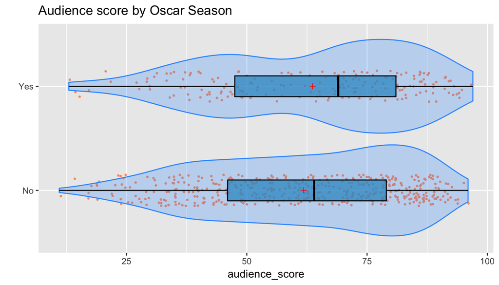

```r
ggplot(movies, aes(x = oscar_season, y = audience_score)) + geom_jitter(colour = "#FF9966", size = .5, width = .15) + geom_violin(colour = "#3399FF", fill = adjustcolor("#3399FF", alpha = .25)) + geom_boxplot(width = .2, colour = "black", fill = adjustcolor("#3399CC", alpha = .75)) + ggtitle("Audience score by Oscar Season") + coord_flip() + xlab("") + stat_summary(fun.y = mean, shape = 3, col = 'red', geom = 'point')
```

```r
regression4 <- lm(formula = audience_score ~ (oscar_season - 1), data = movies)
summary(regression4)
```

```
##
## Call:
## lm(formula = audience_score ~ (oscar_season - 1), data = movies)
##
## Residuals:
##     Min      1Q  Median      3Q     Max
## -50.813 -15.813   3.187  17.251  34.187
##
## Coefficients:
##                 Estimate Std. Error t value Pr(>|t|)
## oscar_seasonNo   61.8130     0.9428   65.56   <2e-16 ***
## oscar_seasonYes  63.6859     1.4631   43.53   <2e-16 ***
## ---
## Signif. codes:  0 '***' 0.001 '**' 0.01 '*' 0.05 '.' 0.1 ' ' 1
##
## Residual standard error: 20.22 on 649 degrees of freedom
## Multiple R-squared:  0.9052, Adjusted R-squared:  0.9049
## F-statistic:  3097 on 2 and 649 DF,  p-value: < 2.2e-16
```

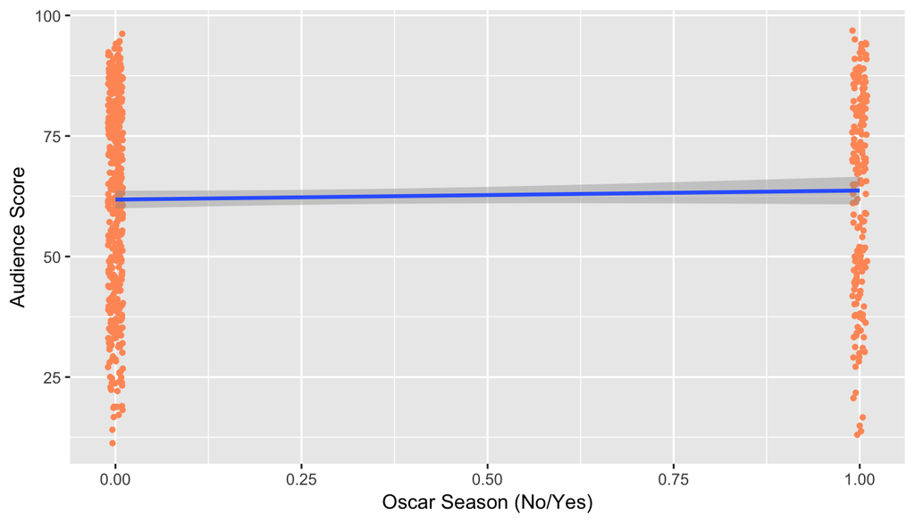

```r
ggplot(movies, aes(x = as.numeric(as.factor(oscar_season)) - 1, y = audience_score)) + geom_jitter(colour = "#FF9966", size = 1, width = 0.01) + geom_smooth(method = "lm", se = TRUE) + xlab("Oscar Season (No/Yes)") + ylab("Audience Score")
```

Between oscar_season and audience_score there is a slightly positive association of hardly two points, on average.

### *Audience Score by Summer Season*

```r
movies %>% group_by(summer_season) %>% summarise(count = n(), mean_x = mean(audience_score), sd_x = sd(audience_score), median_x = median(audience_score), min_x = min(audience_score), max_x = max(audience_score), skew_x = skewness(audience_score))
```

```
## # A tibble: 2 x 8
##   summer_season count   mean_x     sd_x median_x min_x max_x     skew_x
##           <chr> <int>    <dbl>    <dbl>    <dbl> <dbl> <dbl>      <dbl>
## 1            No   443 62.62302 20.38565       66    13    97 -0.3589851
## 2           Yes   208 61.80769 19.90828       65    11    94 -0.3833989
```

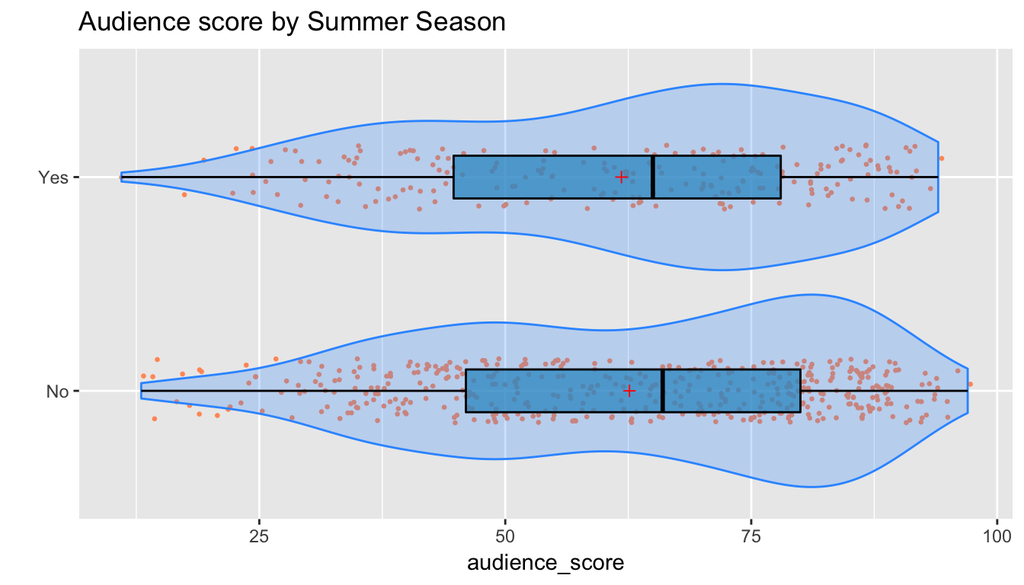

```r
ggplot(movies, aes(x = summer_season, y = audience_score)) + geom_jitter(colour = "#FF9966", size = .5, width = .15) + geom_violin(colour = "#3399FF", fill = adjustcolor("#3399FF", alpha = .25)) + geom_boxplot(width = .2, colour = "black", fill = adjustcolor("#3399CC", alpha = .75)) + ggtitle("Audience score by Summer Season") + coord_flip() + xlab("") + stat_summary(fun.y = mean, shape = 3, col = 'red', geom = 'point')
```

```r
regression5 <- lm(formula = audience_score ~ (summer_season - 1), data = movies)
summary(regression5)
```

```
##
## Call:
## lm(formula = audience_score ~ (summer_season - 1), data = movies)
##
## Residuals:
##     Min      1Q  Median      3Q     Max
## -50.808 -16.623   3.192  17.377  34.377
##
## Coefficients:
##                  Estimate Std. Error t value Pr(>|t|)
## summer_seasonNo   62.6230     0.9614   65.14   <2e-16 ***
## summer_seasonYes  61.8077     1.4030   44.05   <2e-16 ***
## ---
## Signif. codes:  0 '***' 0.001 '**' 0.01 '*' 0.05 '.' 0.1 ' ' 1
##
## Residual standard error: 20.23 on 649 degrees of freedom
## Multiple R-squared:  0.905,  Adjusted R-squared:  0.9047
## F-statistic:  3092 on 2 and 649 DF,  p-value: < 2.2e-16
```

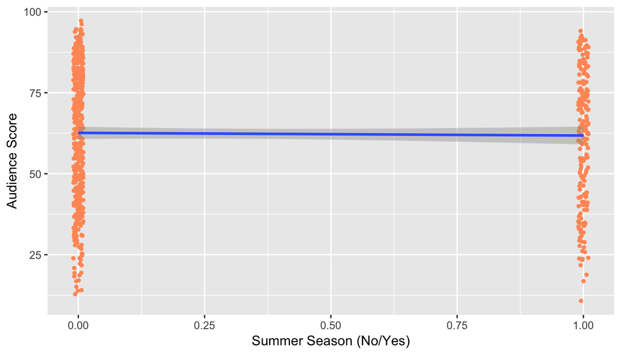

```r
ggplot(movies, aes(x = as.numeric(as.factor(summer_season)) - 1, y = audience_score)) + geom_jitter(colour = "#FF9966", size = 1, width = 0.01) + geom_smooth(method = "lm", se = TRUE) + xlab("Summer Season (No/Yes)") + ylab("Audience Score")
```

Between summer_season and audience_score, on the contrary, what we find is an almost insignificant association (a negative association of less than one point).

## Part 4: Modeling

### *Full model*

In order to conduct the process of model selection, we implemented the BMA (Bayesian model averaging). We assigned equal probabilities to all models (modelprior = uniform), and we use as criteria for being included in the final model the Bayesian Information Criterion (prior = “BIC”), that is to say, the model will be that with the lowest BIC.

```r
bma_aud_score <- bas.lm(audience_score ~ feature_film + drama + runtime + mpaa_rating_R + thtr_rel_year + oscar_season + summer_season + imdb_rating + imdb_num_votes + critics_score + best_pic_nom + best_pic_win + best_actor_win + best_actress_win + best_dir_win + top200_box, data = na.omit(movies), prior = "BIC", modelprior = uniform())
bma_aud_score
```

```
##
## Call:
## bas.lm(formula = audience_score ~ feature_film + drama + runtime +     mpaa_rating_R + thtr_rel_year + oscar_season + summer_season +     imdb_rating + imdb_num_votes + critics_score + best_pic_nom +     best_pic_win + best_actor_win + best_actress_win + best_dir_win +     top200_box, data = na.o…
##
##
##  Marginal Posterior Inclusion Probabilities:
##           Intercept      feature_filmYes             dramaYes
##             1.00000              0.06010              0.04403
##             runtime     mpaa_rating_RYes        thtr_rel_year
##             0.50992              0.05888              0.08277
##     oscar_seasonYes     summer_seasonYes          imdb_rating
##             0.06530              0.07989              1.00000
##      imdb_num_votes        critics_score      best_pic_nomyes
##             0.06247              0.91927              0.13346
##     best_pic_winyes    best_actor_winyes  best_actress_winyes
##             0.04079              0.11483              0.14605
##     best_dir_winyes        top200_boxyes
##             0.06762              0.04968
```

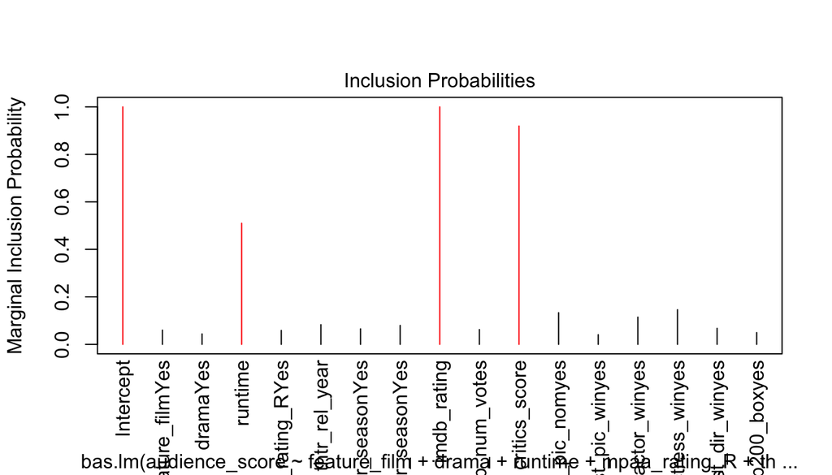

```r
plot(bma_aud_score, which = 4)
```

As we can see above, apart form the intercept, there are three variables whose marginal posterior probability is above 0.50: imdb_rating (1.00), critics_score (0.92) and runtime (0.51). This is also obvious in the fourth chart plotting marginal inclusion probability by inclusion probabilities.

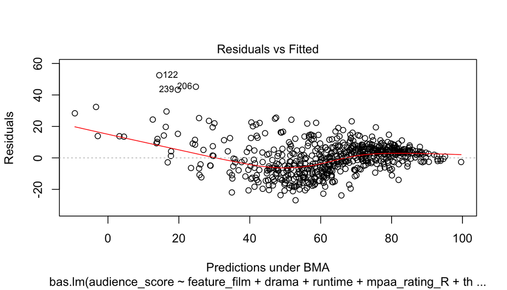

```r
plot(bma_aud_score, which = 1, add.smooth = TRUE)
```

As we see in the plot of the residuals, it appears that there might be three outliers in the data: observations 122, 206, and 239.

```r
summary(bma_aud_score)
```

```
##      Intercept feature_filmYes dramaYes runtime mpaa_rating_RYes
## [1,]         1               0        0       1                0
## [2,]         1               0        0       0                0
## [3,]         1               0        0       0                0
## [4,]         1               0        0       1                0
## [5,]         1               0        0       0                0
##      thtr_rel_year oscar_seasonYes summer_seasonYes imdb_rating
## [1,]             0               0                0           1
## [2,]             0               0                0           1
## [3,]             0               0                0           1
## [4,]             0               0                0           1
## [5,]             0               0                0           1
##      imdb_num_votes critics_score best_pic_nomyes best_pic_winyes
## [1,]              0             1               0               0
## [2,]              0             1               0               0
## [3,]              0             1               0               0
## [4,]              0             1               1               0
## [5,]              0             1               0               0
##      best_actor_winyes best_actress_winyes best_dir_winyes top200_boxyes
## [1,]                 0                   0               0             0
## [2,]                 0                   0               0             0
## [3,]                 0                   1               0             0
## [4,]                 0                   0               0             0
## [5,]                 1                   0               0             0
##             BF PostProbs     R2 dim   logmarg
## [1,] 1.0000000    0.1756 0.7483   4 -3434.752
## [2,] 0.8715404    0.1530 0.7455   3 -3434.889
## [3,] 0.2048238    0.0360 0.7470   4 -3436.338
## [4,] 0.1851908    0.0325 0.7495   5 -3436.438
## [5,] 0.1745817    0.0307 0.7469   4 -3436.497
```

The posterior probability of the most likely model, that including imdb_rating, critics_score and runtime is 17.6%; the second model (the same but excluding runtime) has a posterior probability of 15.3%. Both together accumulate approximately one-third of the total posterior probability. The following model, on the contrary, one represents a posterior probability of 3.6%.

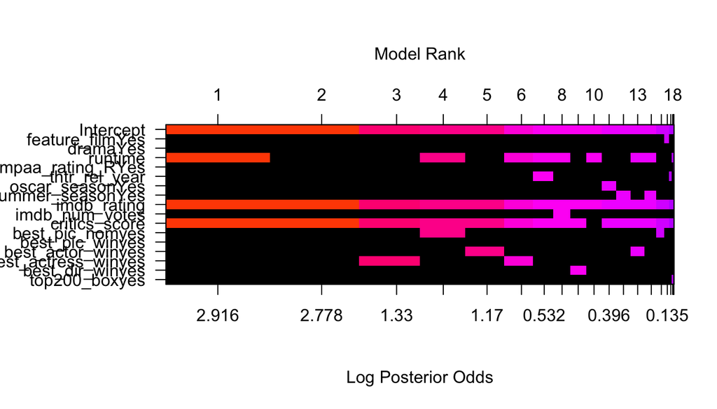

```r
image(bma_aud_score, rotate = FALSE)
```

When we have a look at the chart (model rank), it seems obvious that imdb_rating and critics_score are to be included in the refined models (they appear in most of the first models, those with higher log posterior odds). Runtime, on the contrary, looks like a less reliable variable.

Let’s now visualise the posterior distribution of the coefficients of the three above-mentioned variables:

```r
coef_bma_aud <- coefficients(bma_aud_score)
confint(coef_bma_aud)
```

```
##                            2.5  %      97.5  %          beta
## Intercept           61.3814166833 6.299499e+01  6.221002e+01
## feature_filmYes     -0.8869406248 9.928208e-02 -9.688519e-02
## dramaYes             0.0000000000 0.000000e+00  1.739804e-02
## runtime             -0.0896895247 1.915827e-06 -3.011778e-02
## mpaa_rating_RYes    -0.7387383828 3.169336e-02 -9.500780e-02
## thtr_rel_year       -0.0491757627 0.000000e+00 -4.053622e-03
## oscar_seasonYes     -0.6528709819 4.923399e-03 -6.303298e-02
## summer_seasonYes     0.0000000000 1.155660e+00  8.766201e-02
## imdb_rating         13.5325731303 1.647283e+01  1.489430e+01
## imdb_num_votes       0.0000000000 2.606483e-06  2.479433e-07
## critics_score        0.0000000000 1.129892e-01  6.949175e-02
## best_pic_nomyes     -0.0005159242 5.172283e+00  5.216878e-01
## best_pic_winyes      0.0000000000 0.000000e+00 -6.900706e-03
## best_actor_winyes   -2.2268385473 0.000000e+00 -2.101496e-01
## best_actress_winyes -2.9383464578 0.000000e+00 -3.272276e-01
## best_dir_winyes     -1.4823068259 0.000000e+00 -1.210105e-01
## top200_boxyes        0.0000000000 0.000000e+00  9.544568e-02
## attr(,"Probability")
## [1] 0.95
## attr(,"class")
## [1] "confint.bas"
```

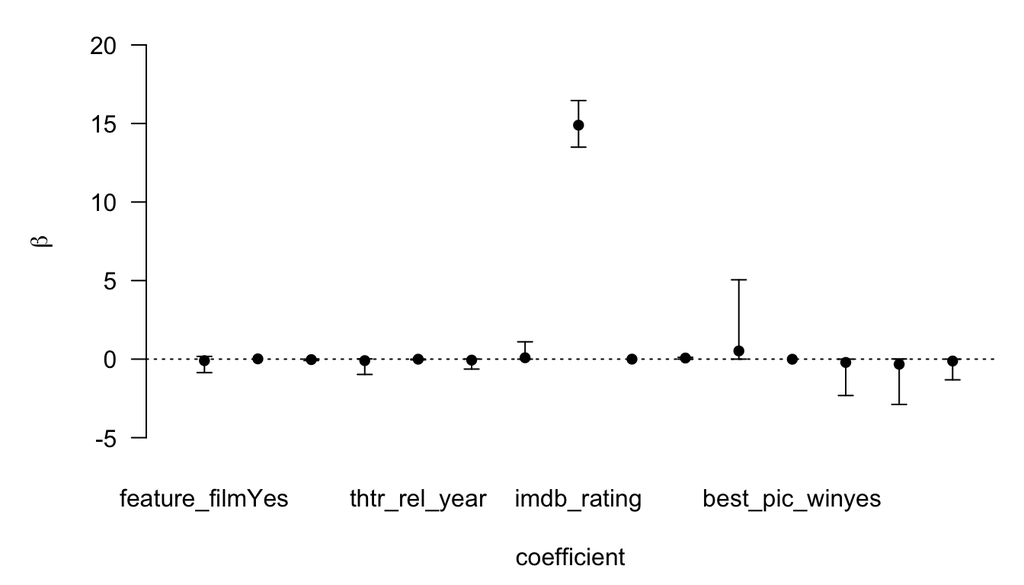

```r
plot(confint(coef_bma_aud, parm=2:16))
```

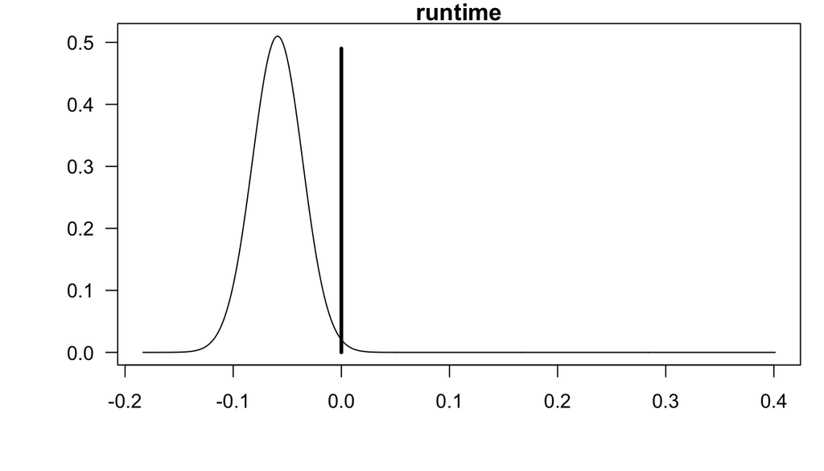

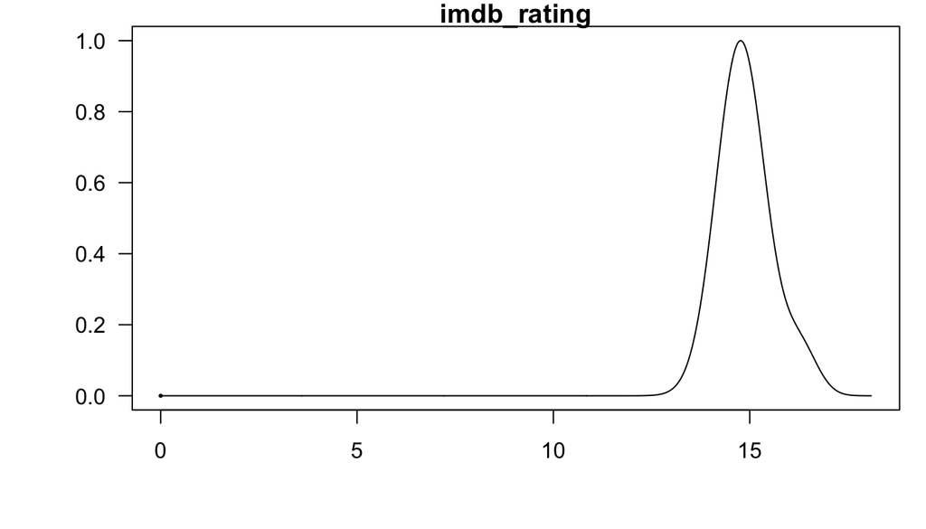

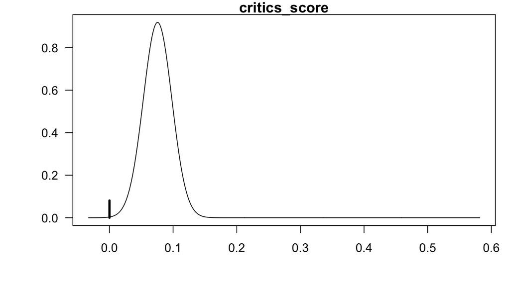

```r
plot(coef_bma_aud, subset = c(4, 9, 11))
```

This confirms what we suggested above, runtime’s distribution is much closer to zero than the other two variables. Its inclusion in the final model, then, might be disputable.

### *Model selection*

```r
bma_aud_score <- bas.lm(audience_score ~ feature_film + drama + runtime + mpaa_rating_R + thtr_rel_year + oscar_season + summer_season + imdb_rating + imdb_num_votes + critics_score + best_pic_nom + best_pic_win + best_actor_win + best_actress_win + best_dir_win + top200_box, data = na.omit(movies), prior = "BIC", modelprior = uniform())
best <- which.max(bma_aud_score$logmarg)
bestmodel <- bma_aud_score$which[[best]]
bestmodel
```

```
## [1]  0  3  8 10
```

```r
bestgamma <- rep(0, bma_aud_score$n.vars)
bestgamma[bestmodel + 1] = 1
bestgamma
```

```
##  [1] 1 0 0 1 0 0 0 0 1 0 1 0 0 0 0 0 0
```

```r
best_bma_aud <- bas.lm(audience_score ~ feature_film + drama + runtime + mpaa_rating_R + thtr_rel_year + oscar_season + summer_season + imdb_rating + imdb_num_votes + critics_score + best_pic_nom + best_pic_win + best_actor_win + best_actress_win + best_dir_win + top200_box, data = na.omit(movies), prior = "BIC", n.models = 1, bestmodel=bestgamma, modelprior= uniform())
best_bma_aud
```

```
##
## Call:
## bas.lm(formula = audience_score ~ feature_film + drama + runtime +     mpaa_rating_R + thtr_rel_year + oscar_season + summer_season +     imdb_rating + imdb_num_votes + critics_score + best_pic_nom +     best_pic_win + best_actor_win + best_actress_win + best_dir_win +     top200_box, data = na.o…
##
##
##  Marginal Posterior Inclusion Probabilities:
##           Intercept      feature_filmYes             dramaYes
##                   1                    0                    0
##             runtime     mpaa_rating_RYes        thtr_rel_year
##                   1                    0                    0
##     oscar_seasonYes     summer_seasonYes          imdb_rating
##                   0                    0                    1
##      imdb_num_votes        critics_score      best_pic_nomyes
##                   0                    1                    0
##     best_pic_winyes    best_actor_winyes  best_actress_winyes
##                   0                    0                    0
##     best_dir_winyes        top200_boxyes
##                   0                    0
```

```r
coef_best_bma_aud <- coefficients(best_bma_aud)
confint(coef_best_bma_aud)
```

```
##                          2.5  %     97.5  %        beta
## Intercept           61.40899246 63.01103985 62.21001616
## feature_filmYes      0.00000000  0.00000000  0.00000000
## dramaYes             0.00000000  0.00000000  0.00000000
## runtime             -0.10185073 -0.01395968 -0.05790520
## mpaa_rating_RYes     0.00000000  0.00000000  0.00000000
## thtr_rel_year        0.00000000  0.00000000  0.00000000
## oscar_seasonYes      0.00000000  0.00000000  0.00000000
## summer_seasonYes     0.00000000  0.00000000  0.00000000
## imdb_rating         13.76724184 16.13362462 14.95043323
## imdb_num_votes       0.00000000  0.00000000  0.00000000
## critics_score        0.03156318  0.11905163  0.07530741
## best_pic_nomyes      0.00000000  0.00000000  0.00000000
## best_pic_winyes      0.00000000  0.00000000  0.00000000
## best_actor_winyes    0.00000000  0.00000000  0.00000000
## best_actress_winyes  0.00000000  0.00000000  0.00000000
## best_dir_winyes      0.00000000  0.00000000  0.00000000
## top200_boxyes        0.00000000  0.00000000  0.00000000
## attr(,"Probability")
## [1] 0.95
## attr(,"class")
## [1] "confint.bas"
```

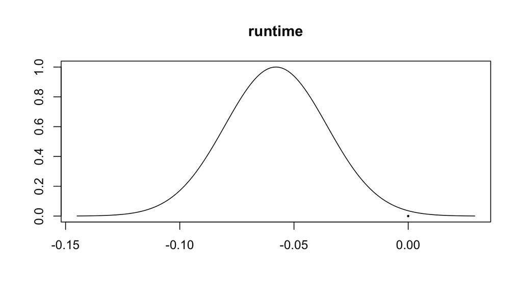

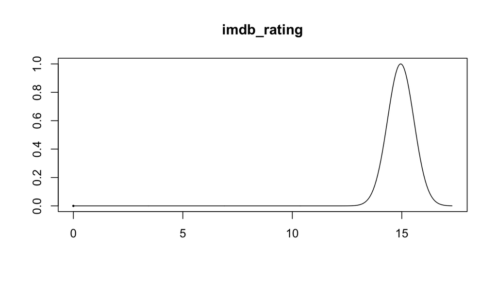

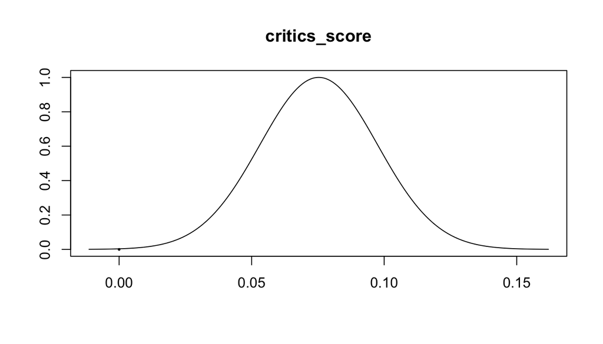

```r
plot(coef_best_bma_aud, subset = c(4, 9, 11))
```

As for the coefficient, they look quite similar. The main difference is that imdb_rating distribution now looks normally distributed. This means that it is no longer correlated with another variable of the model. The best model is summary below:

```r
best_model <- bas.lm(audience_score ~ runtime + critics_score + imdb_rating, data = na.omit(movies), prior = "BIC", modelprior = uniform())
best_model
```

```
##
## Call:
## bas.lm(formula = audience_score ~ runtime + critics_score + imdb_rating,     data = na.omit(movies), prior = "BIC", modelprior = uniform())
##
##
##  Marginal Posterior Inclusion Probabilities:
##     Intercept        runtime  critics_score    imdb_rating
##        1.0000         0.5397         0.9323         1.0000
```

```r
summary(best_model)
```

```
##      Intercept runtime critics_score imdb_rating           BF PostProbs
## [1,]         1       1             1           1 1.000000e+00    0.4982
## [2,]         1       0             1           1 8.715404e-01    0.4342
## [3,]         1       1             0           1 8.330447e-02    0.0415
## [4,]         1       0             0           1 5.252575e-02    0.0262
## [5,]         1       0             1           0 2.820632e-92    0.0000
##          R2 dim   logmarg
## [1,] 0.7483   4 -3434.752
## [2,] 0.7455   3 -3434.889
## [3,] 0.7436   3 -3437.237
## [4,] 0.7405   2 -3437.698
## [5,] 0.4921   2 -3645.553
```

```r
coef_best_model <- coefficients(best_model)
confint(coef_best_model)
```

```
##                    2.5  %    97.5  %        beta
## Intercept     61.42686420 63.0106780 62.21001616
## runtime       -0.08884376  0.0000000 -0.03138428
## critics_score  0.00000000  0.1127117  0.07128748
## imdb_rating   13.56429484 16.5062727 14.89079350
## attr(,"Probability")
## [1] 0.95
## attr(,"class")
## [1] "confint.bas"
```

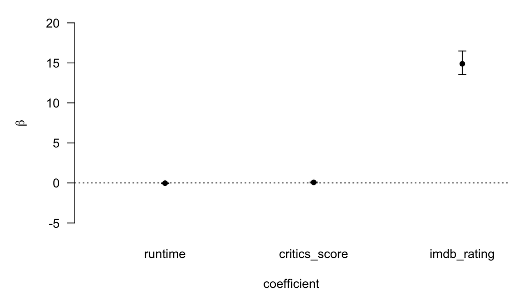

```r
plot(confint(coef_best_model, parm = 2:4))
```

## Part 5: Prediction

For the prediction, we chose the movie “Captain Fantastic” (2016). This movie has been assessed with an 82 by the critics and a 85 by the audience. It lasts 119 minutes and it was scored with 8.0 at IMDb (sources: https://www.rottentomatoes.com/m/captain_fantastic#contentReviews; and http://www.imdb.com/title/tt3553976/).

```r
capFan <- data.frame(audience_score = 85, critics_score = 82, runtime = 119, imdb_rating = 8.0)
capFan_pre <- predict.bas(best_model, newdata = capFan, estimator = "BMA", se.fit = TRUE)
capFan_pre$fit
```

```
##          [,1]
## [1,] 86.12095
```

As we can see, the model predicts the score of the film to be 86.12, a bit over the 85 (the actual score).

## Part 6: Conclusion

The analysis shown above constitute one of the many models can be achieved employing a Bayesian persepctives. We limited ourselves to the use of BMA and BIC (which tries to balance accuracy in prediction with parsimony in the model), but several others criteria could be employed (e.g. BPM, HPM, and the like instead of BMA; or ZS-null instead of the BIC). The model shows that, from the many avaialble variables, three of them (runtime, critics_score and imdb_rating) constitute the best combination in BIC terms to predict the audience_score of a given movie. Particularly, the positive association between audience_score and imdb_rating is evident (being its posterior probability of being included in any model almost indisputable). Runtime and critics_score shown a weaker association, nevertheless, their contributions improve the predictions made by imdb_rating on its own.

One potential weakness of the model presented is the existance of three outliers in the data (122, 206, 239). We decided to keep them in the model despite the fact that they might well influence the association presented here.